# 22 Logistic Regression

Author

Affiliation

Vladimir Buskin

Catholic University of Eichstätt-Ingolstadt

## 22.1 Recommended reading

For linguists:

> Levshina (2015: Chapter 12)

> Winter (2020: Chapter 12)

Full theoretical treatment:

> James et al. (2021: Chapter 4)

> Hosmer & Lemeshow (2008)

## 22.2 Preparation

Consider the data from Buskin’s (n.d.)[^1] corpus-study on subject pronoun realisation:

<sup>1</sup> The input data can be downloaded from this OSF repository: https://osf.io/qgnms.

```r
# Load libraries
library(tidyverse)
library(rms)
library(broom)
library(sjPlot)
library(ggeffects)
library(ggpubr)

# Load data
data_pro <- read.csv("INPUT_pronouns.csv", sep = ",", header = TRUE)

# Inspect data
str(data_pro)
```

```
'data.frame':   4838 obs. of  5 variables:
 $ Reference     : chr  "overt" "overt" "overt" "overt" ...
 $ Person        : chr  "3" "3" "3" "3" ...
 $ Register      : chr  "S1A" "S1A" "S1A" "S1A" ...
 $ Variety       : chr  "GB" "GB" "GB" "GB" ...
 $ Referentiality: chr  "referential" "referential" "referential" "referential" ...
```

```r
head(data_pro)
```

```
  Reference Person Register Variety Referentiality
1     overt      3      S1A      GB    referential
2     overt      3      S1A      GB    referential
3     overt      3      S1A      GB    referential
4     overt      3      S1A      GB    referential
5     overt      3      S1A      GB    referential
6     overt      3      S1A      GB    referential
```

- **Target variable**:
  - `Reference` (‘overt’, ‘null’)
- **Explanatory variables**:
  - `Person` (‘1.p.’, ‘2.p’, ‘3.p’ as well as the dummy pronouns ‘it’ and ‘there’)
  - `Register` (the text category in the International Corpus of English; ‘S1A’ are informal conversations, whereas ‘S1B’ comprises formal class lessons)
  - `Variety` (British English ‘GB’, Singapore English ‘SING’ and Hong Kong English ‘HK’), and
  - `Referentiality` (‘referential’ with an identifiable referent or ‘non-referential’ with no/generic reference)

```r
head(data_pro)
```

```
  Reference Person Register Variety Referentiality
1     overt      3      S1A      GB    referential
2     overt      3      S1A      GB    referential
3     overt      3      S1A      GB    referential
4     overt      3      S1A      GB    referential
5     overt      3      S1A      GB    referential
6     overt      3      S1A      GB    referential
```

```r
table(data_pro$Reference)
```

```
 null overt
  174  4664
```

### 22.2.1 Descriptive overview

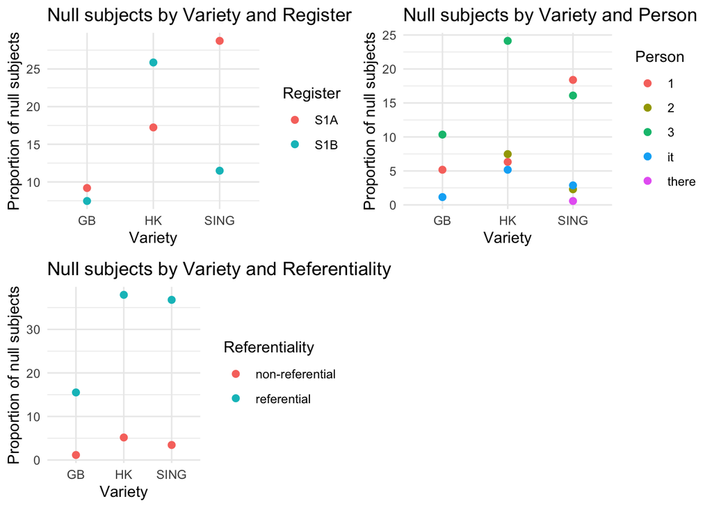

## 22.3 Logistic regression

In contrast to linear regression, logistic regression models a **qualitative response variable** $Y$ with two outcomes[^2]. In the present study, $Y$ is pronominal `Reference` and has the outcomes `Reference = null` and `Reference = overt`, which represent null and overt subjects, respectively. Dichotomous variables of this kind are also often coded as `yes`/`no` or `1`/`0`.

<sup>2</sup> Logistic regression can also be used for $\geq 3$ classes by breaking down the response variable into a series of dichotomous variables. This is also known as **multinomial logistic regression** or **softmax regression.**

Another difference from linear regression is the **output** of the model:

- In linear regression, we obtain a predicted value for the continuous response variable we’re interested in. For instance, if we’re modelling reaction times, the model will return an estimated mean reaction time (given the predictors).
- In logistic regression, however, we either get a **class label** or a **probability**. When modelling pronominal reference, the model will thus either tell us
1. whether a speaker would use an overt or a null subject in a given observation (class prediction).
2. what the probability of using one variant vs. the other would be (probability prediction).

A core component of logistic regression is the **logistic function**. The rationale for using it is that the output of the function will always lie between $0$ and $1$, and it will always denote a **probability**.

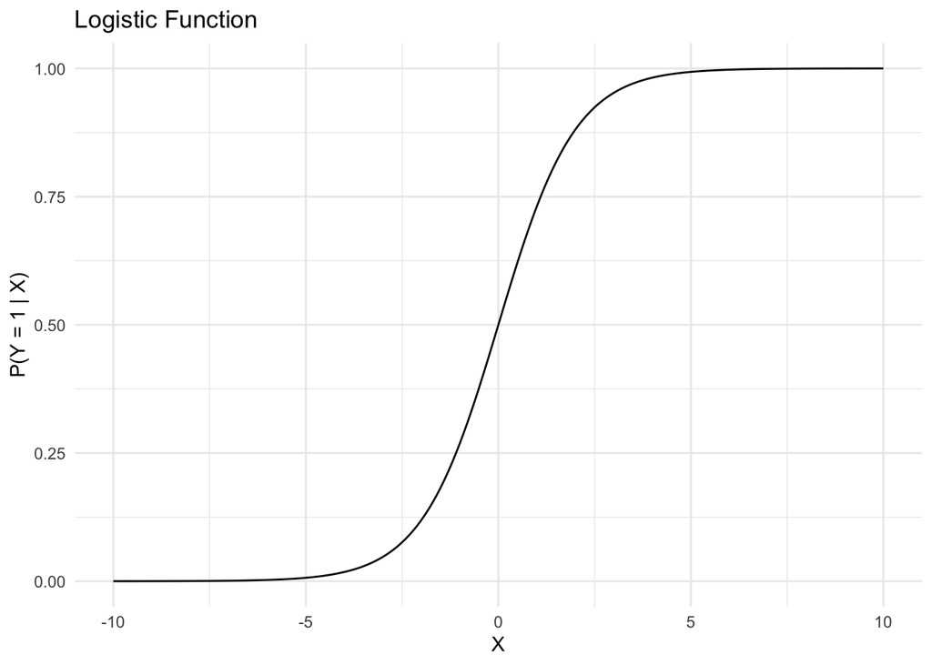

### 22.3.1 The simple logistic model

Assuming a binary response variable $Y$ with the values 1 and 0 and a single predictor $X$, the conditional probability $P(Y = 1 \mid X)$ is then equivalent to the inverse logit in Equation 22.1.

$$P(Y = 1 \mid X) = \frac{e^{\beta_0 + \beta_1X}}{1 + e^{\beta_0 + \beta_1X}}.
\tag{22.1}$$

With some manipulation it can be shaped into a form that is definitely more familiar:

$$\log\left(\frac{P(Y = 1 \mid X)}{1 - P(Y = 1 \mid X)}\right) = \beta_0 + \beta_1X.
\tag{22.2}$$

The logistic model has several characteristic components. The fraction $\frac{P(Y = 1 \mid X)}{1-P(Y = 1 \mid X)}$ represents the **odds**, which stand for to the probability of one outcome (e.g., `Reference = null`) compared to the other (e.g., `Reference = overt`). Their logarithmic transformation are the **log odds** (or **logits**) of one outcome versus the other.

**Understanding log odds**

When interpreting the output of a logistic model, note that

- positive log odds indicate an **increase** in $\frac{P(Y = 1 \mid X)}{1-P(Y = 1 \mid X)}$, whereas
- negative log odds indicate a **decrease** in $\frac{P(Y = 1 \mid X)}{1-P(Y = 1 \mid X)}$.

In more concrete terms: If we are interested in the probability that the form of pronominal reference is `null` (our $Y$) while taking into account the extra-linguistic context (`Register`; our $X$), the model would then have the general form in Equation 22.3.

$$\log\left(\frac{P(\text{Reference} = \text{null} \mid \text{Register})}{1- P(\text{Reference} = \text{null} \mid \text{Register})}\right) = \beta_0 + \beta_1\text{Register}
\tag{22.3}$$

### 22.3.2 Multiple logistic regression

If more than one predictor is included, the above equations can be expanded so as to take into account $p$ slopes for $p$ independent variables $X_1, X_2, ..., X_p$.

$$P(Y = 1 \mid X_1, ..., X_p) = \frac{e^{\beta_0 + \beta_1X_1 + ... + \beta_pX_p}}{1 + e^{\beta_0 + \beta_1X_1 + ... + \beta_pX_p}}.
\tag{22.4}$$

Consequently, the log odds correspond to the sum of linear predictors $\beta_1X_1 + \beta_2X_2 + ...+ \beta_pX_p$ (cf. Equation 22.5).

$$\log\left(\frac{P(Y = 1 \mid X_1, ..., X_p)}{1 - P(Y = 1 \mid X_1, ..., X_p)}\right) = \beta_0 + \sum_{i=1}^{p} \beta_i X_i
\tag{22.5}$$

### 22.3.3 Odds ratios

To assess the strength of an effect, it is instructive to examine the **odds ratios** that correspond to the model coefficients. Odds ratios (OR) are defined as

$$OR(X_1) = e^{\beta_1}.$$

**Understanding odds ratios**

Essentially, the OR describes the ratio between two odds with respect to another independent variable. This is illustrated for `Reference` given `Register` below:

$$\text{OR}(\text{Reference} \mid \text{Register}) = \frac{\frac{P(\text{Reference} = \text{null} \mid \text{Register} = \text{S1A})}{P(\text{Reference} = \text{overt} \mid \text{Register} = \text{S1A})}}{\frac{P(\text{Reference} = \text{null} \mid \text{Register} = \text{S1B})}{P(\text{Reference} = \text{overt} \mid \text{Register} = \text{S1B})}}$$

Read as: ‘**The ratio between** the probability of a null vs. overt object in S1A **and** the probability of a null vs. overt object in S1B’.

## 22.4 Finding $\beta_0$ and $\beta_1$: Maximum Likelihood Estimation

In contrast to continuous data, the estimation of parameters for discrete response variables is less straightforward in that there is no unique solution. Rather than finding a regression line that minimises the distance to all data points, the default approach of logistic models is to find the parameter values that are **most likely**, given the data. Hence this procedure is also known as **Maximum Likelihood Estimation** (MLE).

The model first makes an assumption about the probability distribution of the data. For categorical data, the binomial distribution is a common choice. Equation 22.6 indicates the corresponding probability mass function, which describes the probability $\pi$ of observing $y$ successes in $k$ independent Bernoulli trials. In other words, if we tossed a coin $n = 10$ times and observed $y = 5$ heads (i.e., 5 successes), what is the probability $\pi$ of a success?

$$f(y; k; \pi) = \binom{k}{y} \pi^y (1 - \pi)^{n-y}
\tag{22.6}$$

Now, let $\beta$ denote some parameter of interest (e.g., the slope coefficient of a logistic regression model). Given some observed data, likelihood of this parameter can be described in terms of the likelihood function $L(\beta)$ in Equation 22.7. It assumes $n$ binomial probability mass functions with trials $k = 1$ and computes their product. Since the binomial coefficient $\binom{n}{y}$ is a constant term, it is typically dropped. In essence, we’re multiplying successes $\pi^{y_i}_i$ with failures $(1 - \pi_i)^{1-y_i}$ for each data point.

$$L(\beta) = \prod_{i=1}^n \pi^{y_i}_i (1 - \pi_i)^{1-y_i}
\tag{22.7}$$

Conventionally, this expression is log-transformed in order to convert the product into a sum because, for one, sums are easier to handle computationally. The log-likelihood function $\ell(\beta)$ in Equation 22.8 forms the basis for a variety of goodness-of-fit measures used to evaluate logistic regression models.

$$\ell(\beta) = \sum_{i=1}^n y_i \log(\pi_i) + (1 - y_i) \log(1 - \pi_i)
\tag{22.8}$$

The goal is to find the value that maximises $\ell(\beta)$, i.e., the **maximum likelihood estimator** $\hat{\beta}$. Approximate solutions can be attained via iterative optimisation techniques (e.g. Newton-Ralphson). Sometimes the algorithm may fail to find an optimal solution, which R may report as a model convergence error. For further technical details, see Wood (2006: 63-66) or Agresti & Kateri (2022: 291-294).

## 22.5 Workflow in R

### 22.5.1 Research question and hypotheses

**RQ**: How do the intra- and extra-linguistic variables suggested in the literature affect subject pronoun realisation (Definite Null Instantiation) in British English, Singapore English and Hong Kong English?

Given a significance level $\alpha = 0.05$, the hypotheses are:
$$\begin{aligned}
H_0: & \quad \text{None of the predictor coefficients deviate from 0}.\\
H_1: & \quad \text{At least one predictor coefficient deviates from 0}.
\end{aligned}$$

These can be restated mathematically as:

$$\begin{aligned}
H_0: & \quad \beta_1 = \beta_2 = \cdots = \beta_p = 0 \\
H_1: & \quad \text{At least one } \beta_i \neq 0 \text{ for } i \in \{1, 2, \ldots, p\}
\end{aligned}$$

**Caution**

Note that in practice, these hypotheses are rarely stated explicitly in corpus-linguistic publications.

### 22.5.2 Convert to factors and specify reference levels

The next step involves specifying **reference levels** for all categorical variables. This step is very important because it will directly impact the parameter estimation procedure and, consequently, influence our interpretation of the model output.

- The reference level of the response is usually chosen such that it corresponds to the **unmarked or most frequent case**. Since overt pronouns are much more common in the data, the reference level of the `Reference` variable will be set to `Reference = overt`. This way, the model coefficients will directly represent the probability of the **null** **subject** variant (i.e., the special case) given certain predictor configurations.
- The **predictor levels** need to be specified as well. Among other things, we are interested in how the Asian Englishes pattern relative to British English. Therefore, we will define British English as the baseline for comparison.

We will use the following specifications:

| **Variable** | **Factor Levels** | **Preferred Reference level** |
| --- | --- | --- |
| Register | S1A, S1B | S1A |
| Variety | GB, SING, HK | GB |
| Person | 1, 2, 3, *it*, *there* | 3 |
| Referentiality | referential, non-referential | referential |

```r
# Store "Reference" as factor
data_pro$Reference <- as.factor(data_pro$Reference)

## Specify reference level (the 'unmarked' case)
data_pro$Reference <- relevel(data_pro$Reference, "overt")

## Print levels
levels(data_pro$Reference)
```

```
[1] "overt" "null"
```

Repeat the procedure for the remaining categorical variables.

```r
# Store "Register" as factor
data_pro$Register <- as.factor(data_pro$Register)

## Specify reference level
data_pro$Register <- relevel(data_pro$Register, "S1A")

# Store "Variety" as factor
data_pro$Variety <- as.factor(data_pro$Variety)

## Specify reference level
data_pro$Variety <- relevel(data_pro$Variety, "GB")

# Store "Person" as factor
data_pro$Person <- as.factor(data_pro$Person)

## Specify reference level
data_pro$Person <- relevel(data_pro$Person, "3")

# Store "Referentiality" as factor
data_pro$Referentiality <- as.factor(data_pro$Referentiality)

## Specify reference level
data_pro$Referentiality <- relevel(data_pro$Referentiality, "referential")
```

### 22.5.3 Model fitting

There are two functions that can fit logistic models in R: `lrm()` and `glm()`.

**Note**

The model formula below does not include `Referentiality` because several intermediary steps revealed it to be almost completely irrelevant for predicting `Reference`. In addition, the existing (and significant) interaction `Variety:Person` has been excluded to improve the interpretability of the model.

```r
# With lrm(); requires library("rms")

# Fit interaction model
Reference.lrm <- lrm(Reference ~ Register + Variety + Register:Variety + Person, data = data_pro)

# View model statistics
Reference.lrm
```

```
Logistic Regression Model

lrm(formula = Reference ~ Register + Variety + Register:Variety +
    Person, data = data_pro)

                       Model Likelihood      Discrimination    Rank Discrim.
                             Ratio Test             Indexes          Indexes
Obs          4838    LR chi2     120.43      R2       0.092    C       0.729
 overt       4664    d.f.             9     R2(9,4838)0.023    Dxy     0.458
 null         174    Pr(> chi2) <0.0001    R2(9,503.2)0.199    gamma   0.488
max |deriv| 4e-10                            Brier    0.034    tau-a   0.032

                            Coef    S.E.   Wald Z Pr(>|Z|)
Intercept                   -3.4132 0.2746 -12.43 <0.0001
Register=S1B                 0.0269 0.3807   0.07 0.9437
Variety=HK                   0.6712 0.3174   2.11 0.0345
Variety=SING                 1.1193 0.2959   3.78 0.0002
Person=1                    -0.8807 0.1811  -4.86 <0.0001
Person=2                    -1.6441 0.2695  -6.10 <0.0001
Person=it                    0.7897 0.2978   2.65 0.0080
Person=there                -2.5641 1.0095  -2.54 0.0111
Register=S1B * Variety=HK    0.6035 0.4521   1.34 0.1819
Register=S1B * Variety=SING -0.4753 0.4688  -1.01 0.3107
```

```r
# With (glm); available in base R
# Note the additional "family" argument!
Reference.glm <- glm(Reference ~ Register + Variety + Register:Variety + Person, data = data_pro, family = "binomial")

# View model statistics
summary(Reference.glm)
```

[output not shown]

**Stepwise variable selection**

With the function `drop1()`, it is possible to successively remove variables from the complex model to ascertain which ones improve the model significantly (i.e., decrease the deviance and AIC scores).

```r
drop1(Reference.glm, test = "Chisq")
```

```
Single term deletions

Model:
Reference ~ Register + Variety + Register:Variety + Person
                 Df Deviance    AIC    LRT Pr(>Chi)
<none>                1378.4 1398.4
Person            4   1460.2 1472.2 81.828  < 2e-16 ***
Register:Variety  2   1387.5 1403.5  9.100  0.01057 *
---
Signif. codes:  0 '***' 0.001 '**' 0.01 '*' 0.05 '.' 0.1 ' ' 1
```

### 22.5.4 Confidence intervals and odds ratios

```r
# Tidy the model output
tidy_model <- tidy(Reference.glm, conf.int = TRUE)

# Remove intercept, compute odds ratios and their CIs
tidy_model <- tidy_model %>%
  filter(term != "(Intercept)") %>%
  mutate(
    odds_ratio = exp(estimate),
    odds.conf.low = exp(conf.low),
    odds.conf.high = exp(conf.high)
  )
```

### 22.5.5 Visualisation

- Plot model coefficients:

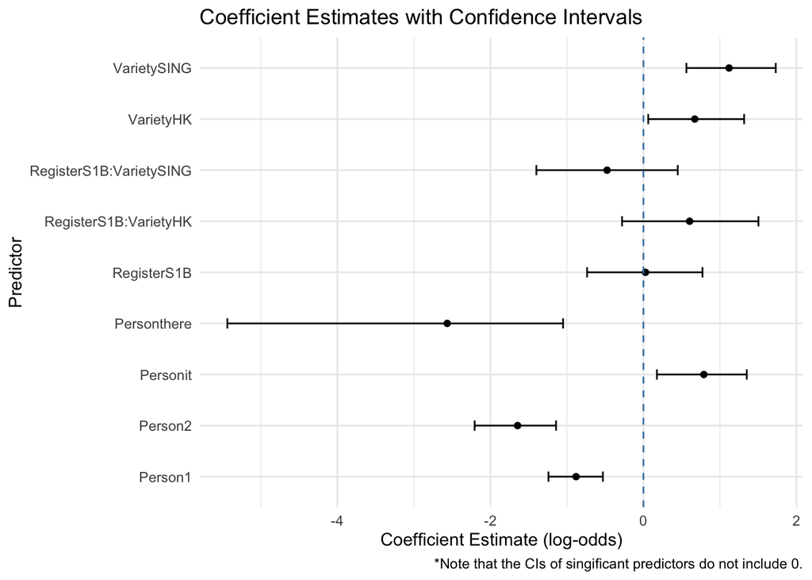

```r
# Create the coefficient plot
ggplot(tidy_model, aes(x = estimate, y = term)) +
  geom_point() +
  geom_errorbarh(aes(xmin = conf.low, xmax = conf.high), height = 0.2) +
  geom_vline(xintercept = 0, linetype = "dashed", color = "steelblue") +
  theme_minimal() +
  labs(
    x = "Coefficient Estimate (log-odds)",
    y = "Predictor",
    title = "Coefficient Estimates with Confidence Intervals",
    caption = "*Note that the CIs of singificant predictors do not include 0."
  )
```

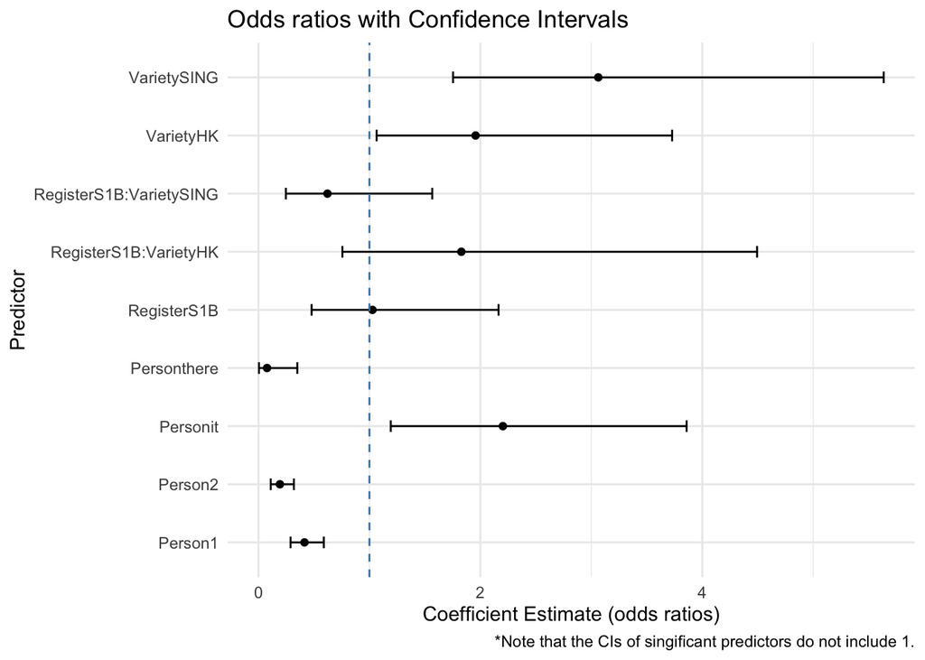

```r
# Plot odds ratios
ggplot(tidy_model, aes(x = exp(estimate), y = term)) +
  geom_point() +
  geom_errorbarh(aes(xmin = odds.conf.low, xmax = odds.conf.high), height = 0.2) +
  geom_vline(xintercept = 1, linetype = "dashed", color = "steelblue") +
  theme_minimal() +
  labs(
    x = "Coefficient Estimate (odds ratios)",
    y = "Predictor",
    title = "Odds ratios with Confidence Intervals",
    caption = "*Note that the CIs of singificant predictors do not include 1."
  )
```

- Plot predicted probabilities:

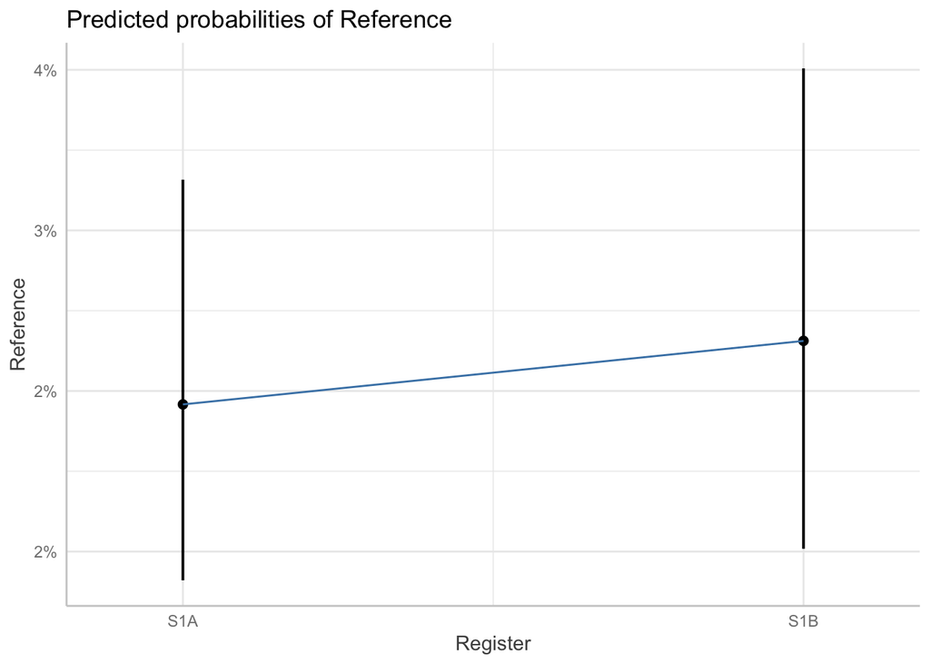

```r
# Use ggeffect() from the ggeffects package
plot(ggeffect(Reference.glm, terms = c("Register"))) + geom_line(col = "steelblue")
```

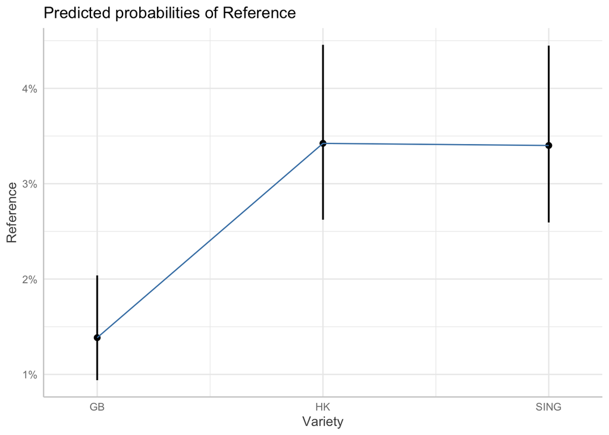

```r
plot(ggeffect(Reference.glm, terms = c("Variety"))) + geom_line(col = "steelblue")
```

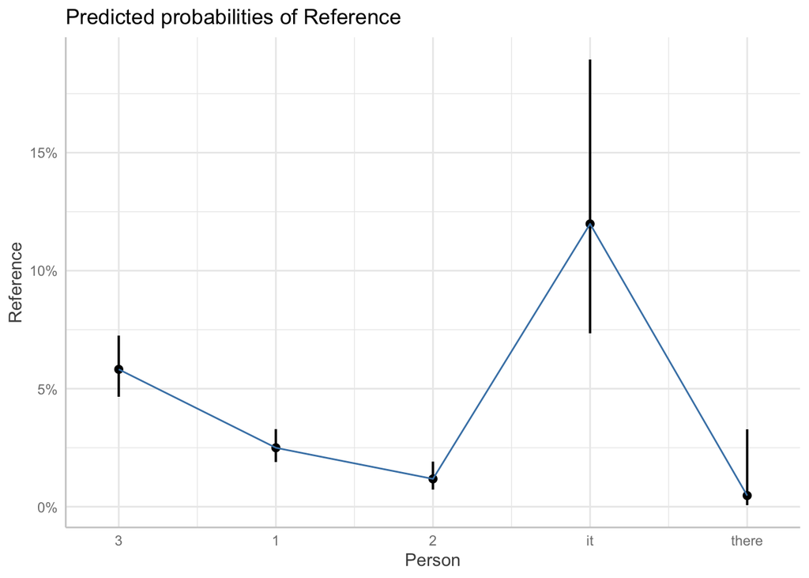

```r
plot(ggeffect(Reference.glm, terms = c("Person"))) + geom_line(col = "steelblue")
```